# lab7

Mitch Holmann, Tucker Southern, Matt McCaskey

1. Generate an approximate AR(1) process y_t with 0 mean and constant variance by first randomly generating the white noise ε_t for t=1,2,3, …,100 then using a truncated version of the MA representation of an AR(1) process for some value of ϕ, where -1< ϕ<1. Specify the ϕ value you used. Attach and describe the time series plot.

```r
set.seed(42)
t <- 1:100
et <- rnorm(t, 0, 1)
```

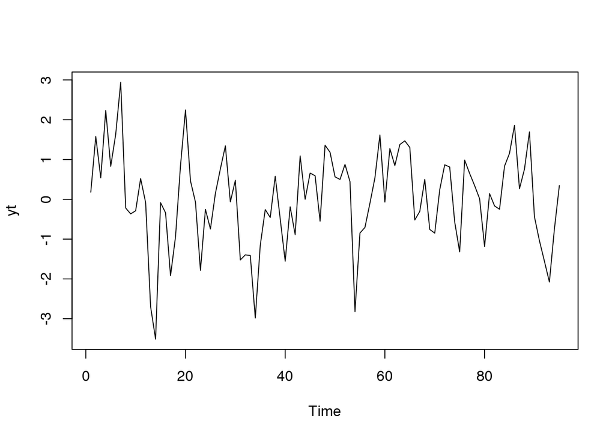

```r
phi <- 0.4
y <- c()
k <- 1:length(et)
for (i in k){
  y[i] <- et[i] + et[i-1]*phi + et[i-2]*phi^2 + et[i-3]*phi^3 + et[i-4]*phi^4 + et[i-5]*phi^5
    }
yt <- y[6:100]
plot.ts(yt)
```

2. Attach and describe the sample ACF and the sample partial ACF of the time series.

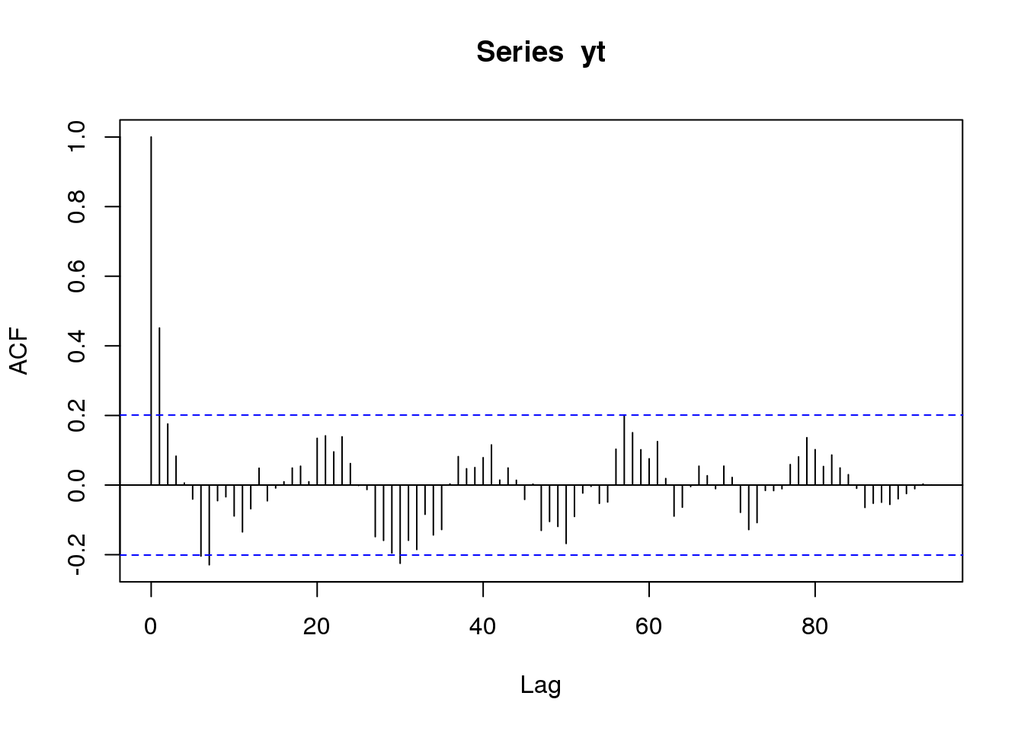

```r
ayt <- acf(yt,95)
```

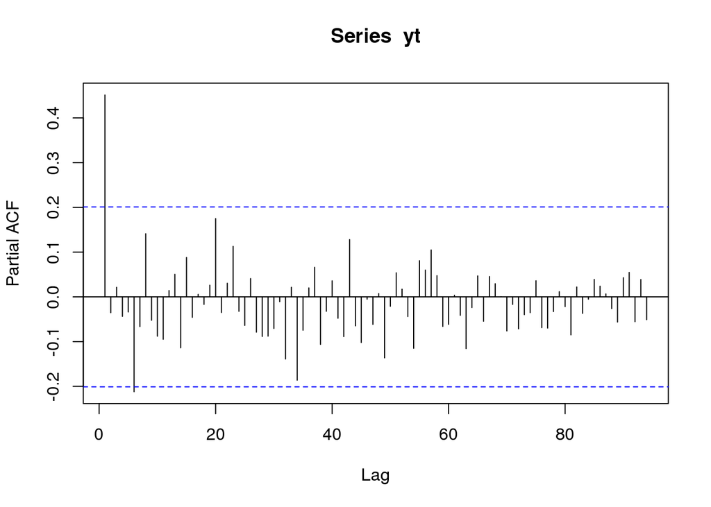

```r
pacf(yt,95)
```

Because the data was generated using an AR(1) process it makes sense that the ACF shows more of a pattern than the partial ACF. Each value was calculated using the previous 5 values and the partial ACF ignores the effect of the intermediate values between the lags.

```r
rho1 <- phi^1
print(rho1)
```

```
## [1] 0.4
```

```r
rho2 <- phi^2
print(rho2)
```

```
## [1] 0.16
```

```r
rho3 <- phi^3
print(rho3)
```

```
## [1] 0.064
```

5. Compare the values in #4 with the corresponding values of the sample autocorrelation.

```r
ayt[1:3]
```

```
##
## Autocorrelations of series 'yt', by lag
##
##     1     2     3
## 0.451 0.175 0.083
```

The values of the theoretical autocorrelation are fairly close to the values shown in the acf plot.

6. Investigate and discuss the effects of changing the value of the parameter ϕ of the AR(1) process on the theoretical Var(y_t) and Cov(y_t,y_(t+1) ).

Given that $\sigma^2$ is the variance of $e_t$…
$$\begin{equation}
Var(y_t) = \frac{\sigma^2}{1-\phi^2}
\end{equation}$$
$$\begin{equation}
Cov(y_t, y_{t+1}) = \frac{\phi \sigma^2}{1-\phi^2}
\end{equation}$$

Based on these functions, we can see that the theoretical Variance and Covariance will increase as $\phi$ gets closer to 1. At $\phi = 0$, $Var(y_t) = \sigma^2$ and $Cov(y_t, y_{t+1}) = 0$. As $\phi$ approaches -1, the Variance will increase, and the Covariance will be a negative value.

7. Are these effects in #6 reflected on the sample ACF? Discuss.

8. Fit an AR(1) model to the time series y_t generated in #1. What are the estimates of the model parameters? Is this model appropriate for the data? Explain.

```r
AR1 <- arima(yt,c(1,0,0))
AR1$coef
```

```
##        ar1  intercept
## 0.44698882 0.02446804
```

The model gives a close estimate of the mean at 0.024468, and $\phi$ at 0.4469888. The actual values for the mean and $\phi$ are 0.0 and 0.4 respectively.

9. Obtain and discuss the sample ACF and sample partial ACF of the residuals after fitting the model.

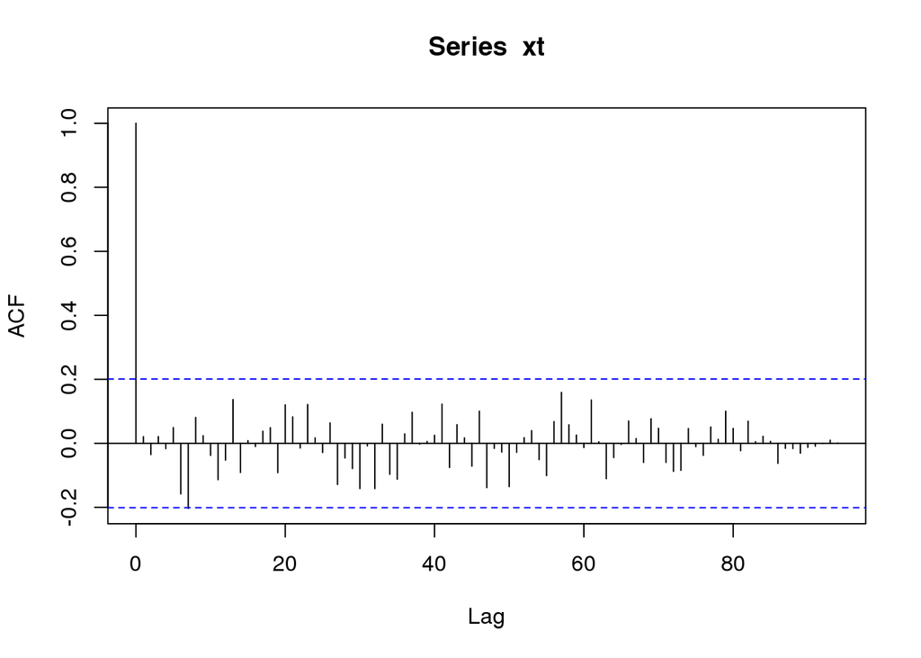

```r
xt <- AR1$residuals
acf(xt,95)
```

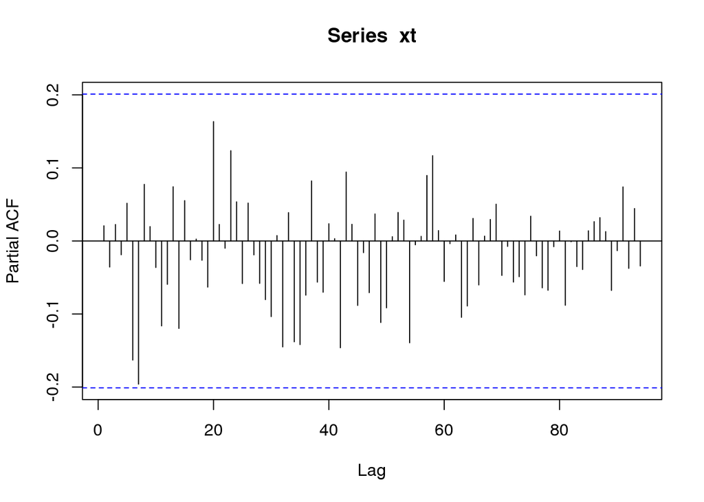

```r
pacf(xt,95)
```

10. Fit an MA(1) model to the time series y_t generated in #1. What are the estimates of the model parameters? Is this an appropriate model for the data? Explain.

```r
theta1 <- .4
ma_y <- c()
for (i in k){
  ma_y[i] <- yt[i] - yt[i-1]*theta1
    }
ma_yt <- ma_y[2:95]
```

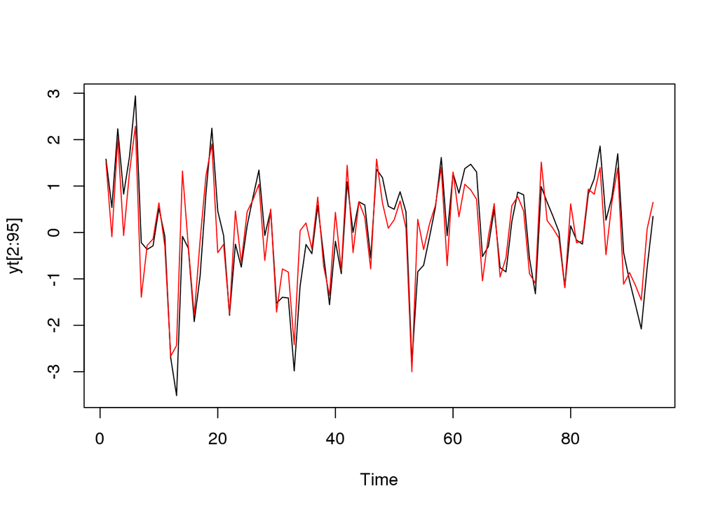

```r
plot.ts(yt[2:95])
lines(ma_yt[1:94], col = "red")
```

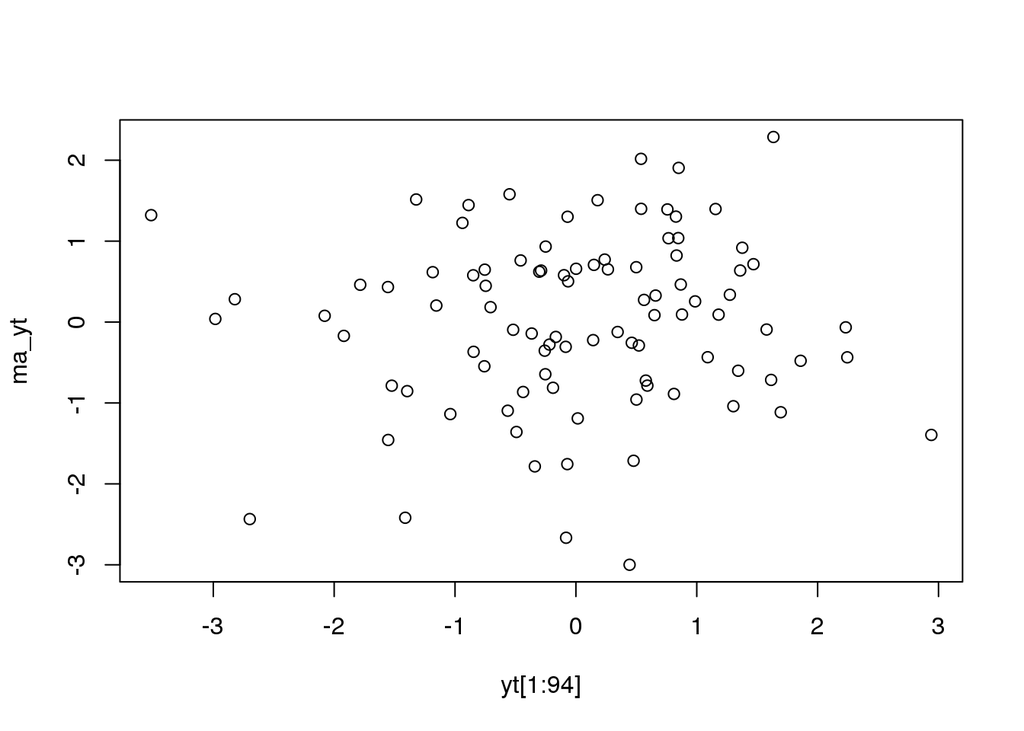

```r
plot(yt[1:94], ma_yt)
```

```r
residuals <- yt[2:94] - ma_yt[1:93]
mean(residuals)
```

```
## [1] 0.01009537
```

```r
var(residuals)
```

```
## [1] 0.226661
```

Based on the plot of $y_t$ and the MA of $y_t$, the MA(1) closely fits the data. This makes sense because the MA(1) process is derived from the data itself. The residuals taken from the data and the MA(1) show a mean of 0, and variance close to 0.2 meaning that the MA(1) is close to the original. The process was done with a $\theta$ value of 0.4.